# 数学建模

### 模型知识点

### 变化模型-微分方程-传染病模型

**Wang Haihua**

🚅 🚋😜 🚑 🚔

# 传染病模型

**问题的提出** ：医生们发现，在一个民族或地区，当某种传染病流传时，波及到的总人数大体上保持为一个常数。即既非所有人都会得病也非毫无规律，两次流行（同种疾病）的波及人数不会相差太大。如何解释这一现象呢？试用建模方法来加以证明。

## 指数模型

定义已感染人数为$i(t)$，假设每个病人单位时间有效接触（足以使人致病）的人数为$\lambda$，那么，在时间段$\Delta t$内，病人的增量可以用如下的公式进行计算 $$ i(t+\Delta t) - i(t) = \lambda i(t)\Delta t $$(exp_infectious_model)

将等式右侧的$\Delta t$除到等式左侧，并 取极限$\Delta t \to 0 $

$$ \lim_{x \to 0} \frac{i(t+\Delta t) - i(t)}{\Delta t} =\lambda i(t) $$

写成微分方程

$$ \frac{\mathrm{d}i}{\mathrm{d}t} = \lambda t $$

计初始时刻的病人人数为$i(0) = i_0$，那么我们可以得到指数增长的传染病模型

$$ \begin{cases} \dfrac{\mathrm{d}i}{\mathrm{d}t} = \lambda t\\ \quad \\ i(0) = i_0 \end{cases} $$

实际上，这与人口增长的指数模型是一致的，我们直接给出其解析解

$$ i(t) = i_0 e^{\lambda t} $$

除了解析解之外，我们还可以使用欧拉前向差分（Forward Euler Method）的方法近似求解上述方程。 将公式{eq}`exp_infectious_model`中的 $i(t)$移到等式的右边，我们得到如下的递推公式

$$ i(t+\Delta t) = i(t) + \lambda i(t)\Delta t $$

以上递推公式意味着，我们可以通过当前时刻的病人人数和致病参数$\lambda$，计算得到$\Delta t$时间后的病人人数，将以上思想在Python中进行实现，代码如下。

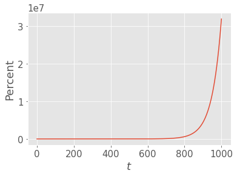

```python
def exp():
    # 输入计算参数
    deltaT = 0.01
    lamb = 2
    i_list = []
    i0 = 0.08; # 初始有8%的人患病
    i_list.append(i0)
    Tot_Time = 10
    TotStep = int(Tot_Time/deltaT)
    ## 递推地求解差分方程
    for i in range(TotStep):
        i_new = i_list[-1] + lamb * i_list[-1] * deltaT
        i_list.append(i_new)
    # 绘图
    plt.plot(i_list)
    plt.xlabel(r"$t$")
    plt.ylabel('Percent')
exp()
```

从中我们可以看到病人的增长是指数级的，在短短十天后，已经有3000万人患病！这显然不符合实际情况的，那么问题出在哪里了呢？

实际上，若病人解除的是病人，并不能够使病人再次患病，实际上以上的算法导致了**重复计数现象**的发生。 解决办法：必须区分已感染者和未感染者。

## SI模型

现在我们将人群分成两个群体：已感染者（病人，**I**nfected）和未感染者（健康者，**S**uspect），该模型称为SI模型，模型假设：

- 在研究时间内，不考虑死亡率和出生率，即总人数$N$不变，病人和健康人的比例分别为$i(t)$和$s(t)$
- 每个病人在单位时间内有效接触并致病的人数为$\lambda$，且只有接触健康人才会致病，称$\lambda$为日接触率

仿照指数模型里面的建模方法，在时间段$\Delta t$内，病人的增量可以用如下的公式进行计算

$$ N[i(t+\Delta t)-i(t)]=[\lambda s(t)] N i(t) \Delta t $$

(si_infectious_model)

其中的$\lambda s(t)$项可以理解为是打折扣以后的传播系数。随着健康人比例的下降，这个系数也会相应下降。

取极限$\Delta t \to 0 $ $$ \frac{\mathrm{d}i}{\mathrm{d}t} = \lambda s i $$

因为$i(t) + s(t) = 1$

所以上式可以变形为 $$ \frac{\mathrm{d}i}{\mathrm{d}t} = \lambda i(1-i) $$

结合初始条件，我们得到了SI模型的微分方程 $$ \begin{cases} \dfrac{\mathrm{d}i}{\mathrm{d}t} = \lambda i(1-i)\\ \quad \\ i(0) = i_0 \end{cases} $$

实际上，这里的SI模型就是我们之前讲到过的人口增长的logistic模型，请你思考如何证明？

这里我们重点考虑用差分方法求解这个方程。在公式{eq}`si_infectious_model`中，消去$N$，再将$i(t)$移到等式的右边，我们得到如下的欧拉前向法递推公式 $$ i(t+\Delta t) = i(t) + \lambda i(t)s(t)\Delta t $$ 同样地，我们可以通过当前时刻的病人人数和致病参数$\lambda$，计算得到$\Delta t$时间后的病人人数，将以上思想在Python中进行实现，代码如下：

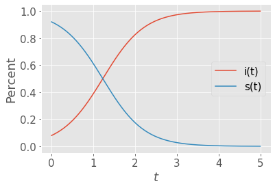

```python
def SI():
    # 输入计算参数
    deltaT = 0.01
    lamb = 2
    i_list = []
    s_list = []
    i0 = 0.08; # 初始有8%的人患病
    i_list.append(i0)
    s_list.append(1 - i0)
    Tot_Time =5
    TotStep = int(Tot_Time/deltaT)
    ## 递推地求解差分方程
    for i in range(TotStep):
        i_new = i_list[-1] + lamb * i_list[-1] * deltaT * s_list[-1]
        i_list.append(i_new)
        s_list.append(1- i_new)
    Time = [i * deltaT for i in range(TotStep + 1)]
    ## 可视化传染过程
    plt.plot(Time,i_list,label = 'i(t)')
    plt.plot(Time,s_list,label = 's(t)')
    plt.xlabel(r"$t$")
    plt.ylabel('Percent')
    plt.legend()
SI()
```

从SI模型我们可以看到，病人比例不再会出现"指数爆炸"的情况，在$t \rightarrow \infty$时最大患病比例为1。在SI模型中，病人数量的增长曲线是一个典型的S型曲线，又称为Logistic曲线，该曲线在生物学上经常被用来描述物种的增长模式。

然而，SI模型的结论告诉我们，**无论$\lambda$多么小，最终人群都会患病**，这显然也是不符合实际情况的。这主要是因为病人患病后无法被治愈。

## SIS模型

现在我们继续将人群分成两个群体：已感染者（病人，**I**nfected）和未感染者（健康者，**S**uspect），但是病人可以被治愈。

该模型称为SIS模型，模型假设：

- 在研究时间内，不考虑死亡率和出生率，即总人数$N$不变，病人和健康人的比例分别为$i(t)$和$s(t)$
- 每个病人在单位时间内有效接触并致病的人数为$\lambda$，且只有接触健康人才会致病，称$\lambda$为日接触率
- **病人每天治愈的比例为$\mu$，称为日治愈率**

在时间段$\Delta t$内，病人的增量可以用如下的公式进行计算 $$ N[i(t+\Delta t)-i(t)]=[\lambda s(t)] N i(t) \Delta t - \mu N i(t) \Delta t $$(sis_infectious_model)

其中新加入的 $\mu N i(t) \Delta t$代表 $ \Delta t$时间内治愈的病人数。

取极限$\Delta t \to 0 $

$$ \frac{\mathrm{d}i}{\mathrm{d}t} = \lambda i(1-i) - \mu i $$

结合初始条件，我们得到了SIS模型的微分方程

$$ \begin{cases} \dfrac{\mathrm{d}i}{\mathrm{d}t} = \lambda i(1-i) - \mu i \\ \quad \\ i(0) = i_0 \end{cases} $$

这个模型难以求出解析解，我们继续采用差分近似的方法求解。在公式{eq}`sis_infectious_model`中消去$N$，再将$i(t)$移到等式的右边，我们得到如下的递推公式

$$ i(t+\Delta t) = i(t) + \lambda i(t)s(t)\Delta t - \mu i(t) \Delta t $$

同样地，我们可以通过当前时刻的病人人数和致病参数$\lambda$,以及治愈参数$\mu$，计算得到$\Delta t$时间后的病人人数，将以上思想在Python中进行实现，代码如下：

```python
import matplotlib.pyplot as plt
def SIS():
    i0 = 0.01; # 初始有1%的人感染
    lamb = 2
    s0 =  1- i0;
    mu = 1.2;
    i_list = []
    s_list = []
    i_list.append(i0)
    s_list.append(s0)
    TotTime = 100
    TimeStep = 0.01
    TotStep = int(TotTime/TimeStep)
    ## 递推地求解差分方程
    for i in range(TotStep):
        i_new = i_list[-1] + lamb * s_list[-1] * i_list[-1]*TimeStep - mu *  i_list[-1]*TimeStep
        i_list.append(i_new)
        s_list.append(1-i_new)
    Time = [TimeStep * i for i in range(TotStep+1)]
    ## 可视化传染过程
    plt.plot(Time,i_list)
    plt.plot(Time,s_list)
    plt.xlabel("Time")
    plt.ylabel("Percent")
    plt.legend(["i(t)","s(t)"])
```

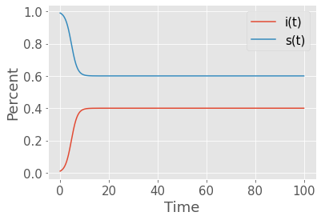

```python
SIS()
```

可以看到，病人的人数和健康人的人数会稳定在一个固定值，并非所有的人都会患病，这个稳定值与 $\lambda$和$\mu$的取值有关。

我们也可以知道，SI模型可以看做是SIS模型在$\mu = 0$时候的特例。

## SIR 模型

有的传染病具有免疫性，病人治愈后即移出系统，称为移出者。

我们将人群分成三个群体：已感染者（病人，**I**nfected）、未感染者（健康者，**S**uspect）和免疫者（**R**emoved），病人被治愈后永久免疫。

在时间段$\Delta t$内，病人的增量可以用如下的公式进行计算

$$ N[i(t+\Delta t)-i(t)]=[\lambda s(t)] N i(t) \Delta t - \mu N i(t) \Delta t $$

健康者的增量为

$$ N[s(t+\Delta t)-s(t)]=-[\lambda s(t)] N i(t) \Delta t $$

取极限$\Delta t \to 0 $，得到如下的微分方程

$$ \begin{cases} \dfrac{\mathrm{d}i}{\mathrm{d}t} = \lambda si - \mu i \\ \quad \\ \dfrac{\mathrm{d}s}{\mathrm{d}t} = - \lambda si\\ \quad \\ i(0) = i_0,s(0) = s_0 \end{cases} $$

```python
def SIR():
    i0 = 0.01; # 初始有1%的人感染
    r0 = 0;# 初始没有人免疫
    lamb = 1.8
    s0 =  1- i0;
    mu = 0.7;
    i_list = []
    s_list = []
    r_list = []
    i_list.append(i0)
    s_list.append(s0)
    r_list.append(r0)
    TotTime = 20
    TimeStep = 0.01
    TotStep = int(TotTime/TimeStep)
    ## 递推地求解差分方程
    for i in range(TotStep):
        i_new = i_list[-1] + lamb * s_list[-1] * i_list[-1]*TimeStep - mu *  i_list[-1]*TimeStep
        s_new = s_list[-1] - lamb * s_list[-1] * i_list[-1]*TimeStep
        i_list.append(i_new)
        s_list.append(s_new)
        r_list.append(1-i_new-s_new)
    Time = [TimeStep * i for i in range(TotStep+1)]
    ## 可视化传染过程
    plt.plot(Time,i_list)
    plt.plot(Time,s_list)
    plt.plot(Time,r_list)
    plt.xlabel("Time")
    plt.ylabel("Percent")
    plt.legend(["i(t)","s(t)","r(t)"])
```

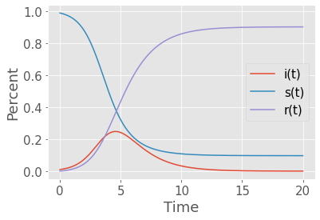

```python
SIR()
```

引入免疫者以后，感染人数会先增后减，有一个峰值。传染病最终后消失。

## 计算结果的对比

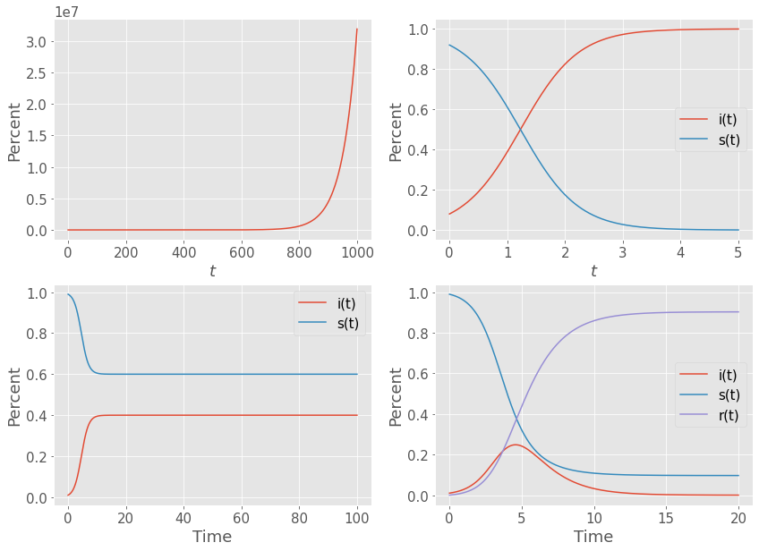

```python
plt.figure(figsize=(14,10))
plt.subplot(2,2,1)
exp()
plt.subplot(2,2,2)
SI()
plt.subplot(2,2,3)
SIS()
plt.subplot(2,2,4)
SIR()
```

**参考文献**

- ThomsonRen 的 github https://github.com/ThomsonRen/mathmodels
- 司守奎 的 《Python数学实验与建模》